# Risk Factor Analysis

## Outcome Variable

**Outcome Variable:** haz

## Predictor Variables

**Intervention Variable:** gagebrth

**Adjustment Set:**

- arm
- sex
- W_mage
- meducyrs
- feducyrs
- hhwealth_quart
- single
- brthmon
- W_parity
- delta_W_mage
- delta_meducyrs
- delta_feducyrs
- delta_hhwealth_quart
- delta_single
- delta_brthmon
- delta_W_parity

## Stratifying Variables

The analysis was stratified on these variable(s):

- agecat
- studyid
- country

## Data Summary

| agecat | studyid | country | gagebrth | n_cell | n |
| --- | --- | --- | --- | --- | --- |
| Birth | ki1000108-CMC-V-BCS-2002 | INDIA | Full or late term | 57 | 90 |
| Birth | ki1000108-CMC-V-BCS-2002 | INDIA | Preterm | 10 | 90 |
| Birth | ki1000108-CMC-V-BCS-2002 | INDIA | Early term | 23 | 90 |
| Birth | ki1000108-IRC | INDIA | Full or late term | 238 | 369 |
| Birth | ki1000108-IRC | INDIA | Preterm | 36 | 369 |
| Birth | ki1000108-IRC | INDIA | Early term | 95 | 369 |
| Birth | ki1000109-EE | PAKISTAN | Full or late term | 0 | 2 |
| Birth | ki1000109-EE | PAKISTAN | Preterm | 1 | 2 |
| Birth | ki1000109-EE | PAKISTAN | Early term | 1 | 2 |
| Birth | ki1000304b-SAS-CompFeed | INDIA | Full or late term | 1 | 187 |
| Birth | ki1000304b-SAS-CompFeed | INDIA | Preterm | 171 | 187 |
| Birth | ki1000304b-SAS-CompFeed | INDIA | Early term | 15 | 187 |
| Birth | ki1017093c-NIH-Crypto | BANGLADESH | Full or late term | 7 | 27 |
| Birth | ki1017093c-NIH-Crypto | BANGLADESH | Preterm | 5 | 27 |
| Birth | ki1017093c-NIH-Crypto | BANGLADESH | Early term | 15 | 27 |
| Birth | ki1101329-Keneba | GAMBIA | Full or late term | 734 | 1515 |
| Birth | ki1101329-Keneba | GAMBIA | Preterm | 235 | 1515 |
| Birth | ki1101329-Keneba | GAMBIA | Early term | 546 | 1515 |
| Birth | ki1119695-PROBIT | BELARUS | Full or late term | 7095 | 13884 |
| Birth | ki1119695-PROBIT | BELARUS | Preterm | 472 | 13884 |
| Birth | ki1119695-PROBIT | BELARUS | Early term | 6317 | 13884 |
| Birth | ki1135781-COHORTS | GUATEMALA | Full or late term | 341 | 617 |
| Birth | ki1135781-COHORTS | GUATEMALA | Preterm | 95 | 617 |
| Birth | ki1135781-COHORTS | GUATEMALA | Early term | 181 | 617 |
| Birth | ki1135781-COHORTS | INDIA | Full or late term | 570 | 1293 |
| Birth | ki1135781-COHORTS | INDIA | Preterm | 285 | 1293 |
| Birth | ki1135781-COHORTS | INDIA | Early term | 438 | 1293 |
| Birth | ki1135781-COHORTS | PHILIPPINES | Full or late term | 1164 | 3024 |
| Birth | ki1135781-COHORTS | PHILIPPINES | Preterm | 649 | 3024 |
| Birth | ki1135781-COHORTS | PHILIPPINES | Early term | 1211 | 3024 |

[output cut: 69 more lines]

The following strata were considered:

- agecat: 24 months, studyid: ki1000108-CMC-V-BCS-2002, country: INDIA
- agecat: 24 months, studyid: ki1000108-IRC, country: INDIA
- agecat: 24 months, studyid: ki1017093c-NIH-Crypto, country: BANGLADESH
- agecat: 24 months, studyid: ki1066203-TanzaniaChild2, country: TANZANIA, UNITED REPUBLIC OF
- agecat: 24 months, studyid: ki1101329-Keneba, country: GAMBIA
- agecat: 24 months, studyid: ki1119695-PROBIT, country: BELARUS
- agecat: 24 months, studyid: ki1135781-COHORTS, country: GUATEMALA
- agecat: 24 months, studyid: ki1135781-COHORTS, country: INDIA
- agecat: 24 months, studyid: ki1135781-COHORTS, country: PHILIPPINES
- agecat: 24 months, studyid: kiGH5241-JiVitA-3, country: BANGLADESH
- agecat: 6 months, studyid: ki1000108-CMC-V-BCS-2002, country: INDIA
- agecat: 6 months, studyid: ki1000108-IRC, country: INDIA
- agecat: 6 months, studyid: ki1000109-EE, country: PAKISTAN
- agecat: 6 months, studyid: ki1000304b-SAS-CompFeed, country: INDIA
- agecat: 6 months, studyid: ki1017093c-NIH-Crypto, country: BANGLADESH
- agecat: 6 months, studyid: ki1066203-TanzaniaChild2, country: TANZANIA, UNITED REPUBLIC OF
- agecat: 6 months, studyid: ki1101329-Keneba, country: GAMBIA
- agecat: 6 months, studyid: ki1119695-PROBIT, country: BELARUS
- agecat: 6 months, studyid: ki1135781-COHORTS, country: GUATEMALA
- agecat: 6 months, studyid: ki1135781-COHORTS, country: INDIA
- agecat: 6 months, studyid: ki1135781-COHORTS, country: PHILIPPINES
- agecat: 6 months, studyid: kiGH5241-JiVitA-3, country: BANGLADESH
- agecat: Birth, studyid: ki1000108-CMC-V-BCS-2002, country: INDIA
- agecat: Birth, studyid: ki1000108-IRC, country: INDIA
- agecat: Birth, studyid: ki1000109-EE, country: PAKISTAN
- agecat: Birth, studyid: ki1000304b-SAS-CompFeed, country: INDIA
- agecat: Birth, studyid: ki1017093c-NIH-Crypto, country: BANGLADESH
- agecat: Birth, studyid: ki1101329-Keneba, country: GAMBIA
- agecat: Birth, studyid: ki1119695-PROBIT, country: BELARUS
- agecat: Birth, studyid: ki1135781-COHORTS, country: GUATEMALA
- agecat: Birth, studyid: ki1135781-COHORTS, country: INDIA
- agecat: Birth, studyid: ki1135781-COHORTS, country: PHILIPPINES
- agecat: Birth, studyid: kiGH5241-JiVitA-3, country: BANGLADESH

### Dropped Strata

Some strata were dropped due to rare outcomes:

- agecat: Birth, studyid: ki1000109-EE, country: PAKISTAN
- agecat: Birth, studyid: ki1000304b-SAS-CompFeed, country: INDIA
- agecat: 24 months, studyid: ki1066203-TanzaniaChild2, country: TANZANIA, UNITED REPUBLIC OF

## Methods Detail

We’re interested in the causal parameters $E[Y_a]$ for all values of $a \in \mathcal{A}$. These parameters represent the mean outcome if, possibly contrary to fact, we intervened to set all units to have $A=a$. Under the randomization and positivity assumptions, these are identified by the statistical parameters $\psi_a=E_W[E_{Y|A,W}(Y|A=a,W)]$. In addition, we’re interested in the mean of $Y$, $E[Y]$ under no intervention (the observed mean). We will estimate these parameters by using SuperLearner to fit the relevant likelihood factors – $E_{Y|A,W}(Y|A=a,W)$ and $p(A=a|W)$, and then updating our likelihood fit using a joint TMLE.

For unadjusted analyses ($W=\{\}$), initial likelihoods were estimated using Lrnr_glm to estimate the simple $E(Y|A)$ and Lrnr_mean to estimate $p(A)$. For adjusted analyses, a small library containing Lrnr_glmnet, Lrnr_xgboost, and Lrnr_mean was used.

Having estimated these parameters, we will then use the delta method to estimate relative risks and attributable risks relative to a prespecified baseline level of $A$.

# Results Detail

## Results Plots

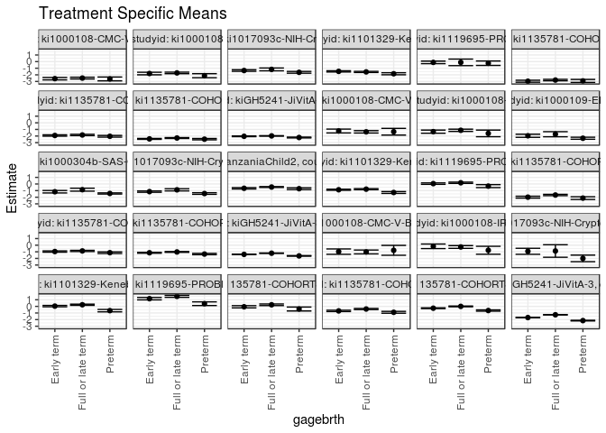

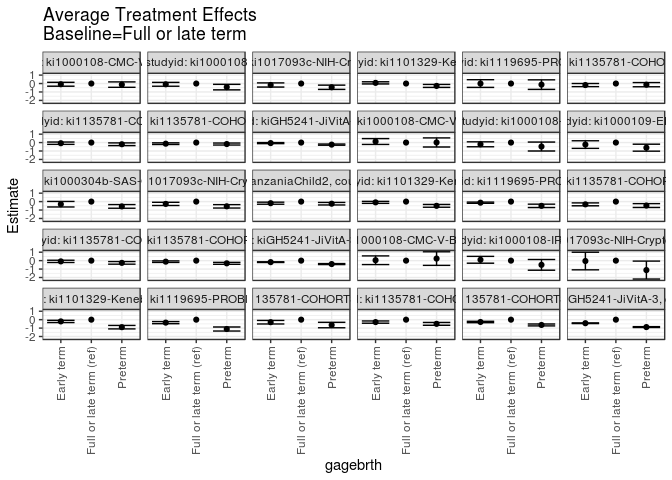

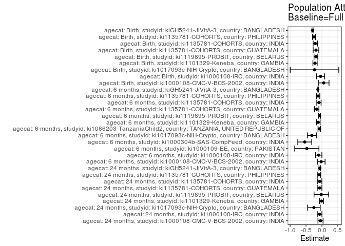

## Results Table

### Parameter: TSM

| agecat | studyid | country | intervention_level | baseline_level | estimate | ci_lower | ci_upper |
| --- | --- | --- | --- | --- | --- | --- | --- |
| Birth | ki1000108-CMC-V-BCS-2002 | INDIA | Full or late term | NA | -1.0221381 | -1.3125459 | -0.7317303 |
| Birth | ki1000108-CMC-V-BCS-2002 | INDIA | Preterm | NA | -0.7764988 | -1.5240040 | -0.0289936 |
| Birth | ki1000108-CMC-V-BCS-2002 | INDIA | Early term | NA | -0.9732742 | -1.3777255 | -0.5688229 |
| Birth | ki1000108-IRC | INDIA | Full or late term | NA | -0.2695938 | -0.4759034 | -0.0632841 |
| Birth | ki1000108-IRC | INDIA | Preterm | NA | -0.7682155 | -1.3679222 | -0.1685088 |
| Birth | ki1000108-IRC | INDIA | Early term | NA | -0.1691765 | -0.5154168 | 0.1770638 |
| Birth | ki1017093c-NIH-Crypto | BANGLADESH | Full or late term | NA | -0.8771429 | -1.8202279 | 0.0659422 |
| Birth | ki1017093c-NIH-Crypto | BANGLADESH | Preterm | NA | -1.9980000 | -2.4964582 | -1.4995418 |
| Birth | ki1017093c-NIH-Crypto | BANGLADESH | Early term | NA | -0.9226667 | -1.3784537 | -0.4668796 |
| Birth | ki1101329-Keneba | GAMBIA | Full or late term | NA | 0.2450873 | 0.1579015 | 0.3322731 |
| Birth | ki1101329-Keneba | GAMBIA | Preterm | NA | -0.6454573 | -0.8297006 | -0.4612139 |
| Birth | ki1101329-Keneba | GAMBIA | Early term | NA | 0.0380939 | -0.0631431 | 0.1393308 |
| Birth | ki1119695-PROBIT | BELARUS | Full or late term | NA | 1.5150480 | 1.3616580 | 1.6684381 |
| Birth | ki1119695-PROBIT | BELARUS | Preterm | NA | 0.4053980 | 0.1282580 | 0.6825380 |
| Birth | ki1119695-PROBIT | BELARUS | Early term | NA | 1.1647503 | 0.9815413 | 1.3479594 |
| Birth | ki1135781-COHORTS | GUATEMALA | Full or late term | NA | 0.2393847 | 0.1148488 | 0.3639205 |
| Birth | ki1135781-COHORTS | GUATEMALA | Preterm | NA | -0.3981183 | -0.6949318 | -0.1013049 |
| Birth | ki1135781-COHORTS | GUATEMALA | Early term | NA | -0.0610572 | -0.2278783 | 0.1057640 |
| Birth | ki1135781-COHORTS | INDIA | Full or late term | NA | -0.3989972 | -0.4880665 | -0.3099278 |
| Birth | ki1135781-COHORTS | INDIA | Preterm | NA | -0.8969477 | -1.0366702 | -0.7572252 |
| Birth | ki1135781-COHORTS | INDIA | Early term | NA | -0.6851543 | -0.7847388 | -0.5855698 |
| Birth | ki1135781-COHORTS | PHILIPPINES | Full or late term | NA | -0.0014048 | -0.0599494 | 0.0571398 |
| Birth | ki1135781-COHORTS | PHILIPPINES | Preterm | NA | -0.6284923 | -0.7251123 | -0.5318723 |
| Birth | ki1135781-COHORTS | PHILIPPINES | Early term | NA | -0.2755782 | -0.3327488 | -0.2184075 |
| Birth | kiGH5241-JiVitA-3 | BANGLADESH | Full or late term | NA | -1.2706179 | -1.2945893 | -1.2466465 |
| Birth | kiGH5241-JiVitA-3 | BANGLADESH | Preterm | NA | -2.1505402 | -2.1965502 | -2.1045302 |
| Birth | kiGH5241-JiVitA-3 | BANGLADESH | Early term | NA | -1.6911437 | -1.7236301 | -1.6586574 |
| 6 months | ki1000108-CMC-V-BCS-2002 | INDIA | Full or late term | NA | -1.3641569 | -1.5472180 | -1.1810959 |
| 6 months | ki1000108-CMC-V-BCS-2002 | INDIA | Preterm | NA | -1.3488343 | -1.8562843 | -0.8413843 |
| 6 months | ki1000108-CMC-V-BCS-2002 | INDIA | Early term | NA | -1.2392346 | -1.5306810 | -0.9477881 |

[output cut: 60 more lines]

### Parameter: E(Y)

| agecat | studyid | country | intervention_level | baseline_level | estimate | ci_lower | ci_upper |
| --- | --- | --- | --- | --- | --- | --- | --- |
| Birth | ki1000108-CMC-V-BCS-2002 | INDIA | NA | NA | -0.9654444 | -1.1742112 | -0.7566777 |
| Birth | ki1000108-IRC | INDIA | NA | NA | -0.3102981 | -0.4751168 | -0.1454794 |
| Birth | ki1017093c-NIH-Crypto | BANGLADESH | NA | NA | -1.1100000 | -1.5086894 | -0.7113106 |
| Birth | ki1101329-Keneba | GAMBIA | NA | NA | 0.0288383 | -0.0354675 | 0.0931441 |
| Birth | ki1119695-PROBIT | BELARUS | NA | NA | 1.3254775 | 1.1669293 | 1.4840258 |
| Birth | ki1135781-COHORTS | GUATEMALA | NA | NA | 0.0530794 | -0.0441925 | 0.1503513 |
| Birth | ki1135781-COHORTS | INDIA | NA | NA | -0.6072158 | -0.6675691 | -0.5468624 |
| Birth | ki1135781-COHORTS | PHILIPPINES | NA | NA | -0.2492460 | -0.2884729 | -0.2100192 |
| Birth | kiGH5241-JiVitA-3 | BANGLADESH | NA | NA | -1.5660681 | -1.5858219 | -1.5463144 |
| 6 months | ki1000108-CMC-V-BCS-2002 | INDIA | NA | NA | -1.3856004 | -1.5319935 | -1.2392073 |
| 6 months | ki1000108-IRC | INDIA | NA | NA | -1.2321263 | -1.3660720 | -1.0981806 |
| 6 months | ki1000109-EE | PAKISTAN | NA | NA | -2.2004704 | -2.3234073 | -2.0775336 |
| 6 months | ki1000304b-SAS-CompFeed | INDIA | NA | NA | -1.4018312 | -1.4804646 | -1.3231978 |
| 6 months | ki1017093c-NIH-Crypto | BANGLADESH | NA | NA | -1.1986783 | -1.2700937 | -1.1272630 |
| 6 months | ki1066203-TanzaniaChild2 | TANZANIA, UNITED REPUBLIC OF | NA | NA | -0.5419570 | -0.5926042 | -0.4913098 |
| 6 months | ki1101329-Keneba | GAMBIA | NA | NA | -0.8948084 | -0.9510697 | -0.8385471 |
| 6 months | ki1119695-PROBIT | BELARUS | NA | NA | 0.1069986 | 0.0122286 | 0.2017686 |
| 6 months | ki1135781-COHORTS | GUATEMALA | NA | NA | -1.8315428 | -1.9081267 | -1.7549589 |
| 6 months | ki1135781-COHORTS | INDIA | NA | NA | -0.9630335 | -1.0220763 | -0.9039908 |
| 6 months | ki1135781-COHORTS | PHILIPPINES | NA | NA | -1.1409862 | -1.1830414 | -1.0989310 |
| 6 months | kiGH5241-JiVitA-3 | BANGLADESH | NA | NA | -1.3404486 | -1.3659169 | -1.3149804 |
| 24 months | ki1000108-CMC-V-BCS-2002 | INDIA | NA | NA | -2.5330857 | -2.6360668 | -2.4301046 |
| 24 months | ki1000108-IRC | INDIA | NA | NA | -1.7805128 | -1.8756216 | -1.6854041 |
| 24 months | ki1017093c-NIH-Crypto | BANGLADESH | NA | NA | -1.4295331 | -1.5127726 | -1.3462935 |
| 24 months | ki1101329-Keneba | GAMBIA | NA | NA | -1.5664092 | -1.6263058 | -1.5065125 |
| 24 months | ki1119695-PROBIT | BELARUS | NA | NA | -0.1314048 | -0.4282725 | 0.1654630 |
| 24 months | ki1135781-COHORTS | GUATEMALA | NA | NA | -2.8606184 | -2.9431264 | -2.7781104 |
| 24 months | ki1135781-COHORTS | INDIA | NA | NA | -1.9130810 | -1.9742771 | -1.8518850 |
| 24 months | ki1135781-COHORTS | PHILIPPINES | NA | NA | -2.3902929 | -2.4353250 | -2.3452608 |
| 24 months | kiGH5241-JiVitA-3 | BANGLADESH | NA | NA | -2.0468674 | -2.0777591 | -2.0159757 |

### Parameter: ATE

| agecat | studyid | country | intervention_level | baseline_level | estimate | ci_lower | ci_upper |
| --- | --- | --- | --- | --- | --- | --- | --- |
| Birth | ki1000108-CMC-V-BCS-2002 | INDIA | Full or late term | Full or late term | 0.0000000 | 0.0000000 | 0.0000000 |
| Birth | ki1000108-CMC-V-BCS-2002 | INDIA | Preterm | Full or late term | 0.2456393 | -0.5612034 | 1.0524821 |
| Birth | ki1000108-CMC-V-BCS-2002 | INDIA | Early term | Full or late term | 0.0488639 | -0.4646915 | 0.5624193 |
| Birth | ki1000108-IRC | INDIA | Full or late term | Full or late term | 0.0000000 | 0.0000000 | 0.0000000 |
| Birth | ki1000108-IRC | INDIA | Preterm | Full or late term | -0.4986217 | -1.1343178 | 0.1370744 |
| Birth | ki1000108-IRC | INDIA | Early term | Full or late term | 0.1004173 | -0.3036353 | 0.5044699 |
| Birth | ki1017093c-NIH-Crypto | BANGLADESH | Full or late term | Full or late term | 0.0000000 | 0.0000000 | 0.0000000 |
| Birth | ki1017093c-NIH-Crypto | BANGLADESH | Preterm | Full or late term | -1.1208571 | -2.1875671 | -0.0541472 |
| Birth | ki1017093c-NIH-Crypto | BANGLADESH | Early term | Full or late term | -0.0455238 | -1.0929737 | 1.0019261 |
| Birth | ki1101329-Keneba | GAMBIA | Full or late term | Full or late term | 0.0000000 | 0.0000000 | 0.0000000 |
| Birth | ki1101329-Keneba | GAMBIA | Preterm | Full or late term | -0.8905446 | -1.0945495 | -0.6865396 |
| Birth | ki1101329-Keneba | GAMBIA | Early term | Full or late term | -0.2069934 | -0.3405167 | -0.0734701 |
| Birth | ki1119695-PROBIT | BELARUS | Full or late term | Full or late term | 0.0000000 | 0.0000000 | 0.0000000 |
| Birth | ki1119695-PROBIT | BELARUS | Preterm | Full or late term | -1.1096500 | -1.3485748 | -0.8707253 |
| Birth | ki1119695-PROBIT | BELARUS | Early term | Full or late term | -0.3502977 | -0.4740631 | -0.2265322 |
| Birth | ki1135781-COHORTS | GUATEMALA | Full or late term | Full or late term | 0.0000000 | 0.0000000 | 0.0000000 |
| Birth | ki1135781-COHORTS | GUATEMALA | Preterm | Full or late term | -0.6375030 | -0.9595967 | -0.3154093 |
| Birth | ki1135781-COHORTS | GUATEMALA | Early term | Full or late term | -0.3004419 | -0.5087861 | -0.0920977 |
| Birth | ki1135781-COHORTS | INDIA | Full or late term | Full or late term | 0.0000000 | 0.0000000 | 0.0000000 |
| Birth | ki1135781-COHORTS | INDIA | Preterm | Full or late term | -0.4979505 | -0.6635872 | -0.3323139 |
| Birth | ki1135781-COHORTS | INDIA | Early term | Full or late term | -0.2861571 | -0.4194322 | -0.1528821 |
| Birth | ki1135781-COHORTS | PHILIPPINES | Full or late term | Full or late term | 0.0000000 | 0.0000000 | 0.0000000 |
| Birth | ki1135781-COHORTS | PHILIPPINES | Preterm | Full or late term | -0.6270875 | -0.7400449 | -0.5141301 |
| Birth | ki1135781-COHORTS | PHILIPPINES | Early term | Full or late term | -0.2741734 | -0.3560136 | -0.1923331 |
| Birth | kiGH5241-JiVitA-3 | BANGLADESH | Full or late term | Full or late term | 0.0000000 | 0.0000000 | 0.0000000 |
| Birth | kiGH5241-JiVitA-3 | BANGLADESH | Preterm | Full or late term | -0.8799223 | -0.9321910 | -0.8276537 |
| Birth | kiGH5241-JiVitA-3 | BANGLADESH | Early term | Full or late term | -0.4205259 | -0.4580951 | -0.3829566 |
| 6 months | ki1000108-CMC-V-BCS-2002 | INDIA | Full or late term | Full or late term | 0.0000000 | 0.0000000 | 0.0000000 |
| 6 months | ki1000108-CMC-V-BCS-2002 | INDIA | Preterm | Full or late term | 0.0153226 | -0.5253321 | 0.5559773 |
| 6 months | ki1000108-CMC-V-BCS-2002 | INDIA | Early term | Full or late term | 0.1249223 | -0.2220581 | 0.4719027 |

[output cut: 60 more lines]

### Parameter: PAR

| agecat | studyid | country | intervention_level | baseline_level | estimate | ci_lower | ci_upper |
| --- | --- | --- | --- | --- | --- | --- | --- |
| Birth | ki1000108-CMC-V-BCS-2002 | INDIA | Full or late term | NA | 0.0566937 | -0.1110043 | 0.2243917 |
| Birth | ki1000108-IRC | INDIA | Full or late term | NA | -0.0407043 | -0.1670634 | 0.0856548 |
| Birth | ki1017093c-NIH-Crypto | BANGLADESH | Full or late term | NA | -0.2328571 | -0.9991387 | 0.5334244 |
| Birth | ki1101329-Keneba | GAMBIA | Full or late term | NA | -0.2162490 | -0.2835401 | -0.1489579 |
| Birth | ki1119695-PROBIT | BELARUS | Full or late term | NA | -0.1895705 | -0.2480175 | -0.1311235 |
| Birth | ki1135781-COHORTS | GUATEMALA | Full or late term | NA | -0.1863053 | -0.2756681 | -0.0969424 |
| Birth | ki1135781-COHORTS | INDIA | Full or late term | NA | -0.2082186 | -0.2766944 | -0.1397428 |
| Birth | ki1135781-COHORTS | PHILIPPINES | Full or late term | NA | -0.2478412 | -0.2962059 | -0.1994765 |
| Birth | kiGH5241-JiVitA-3 | BANGLADESH | Full or late term | NA | -0.2954502 | -0.3133811 | -0.2775194 |
| 6 months | ki1000108-CMC-V-BCS-2002 | INDIA | Full or late term | NA | -0.0214435 | -0.1424350 | 0.0995480 |
| 6 months | ki1000108-IRC | INDIA | Full or late term | NA | -0.0998557 | -0.1994583 | -0.0002531 |
| 6 months | ki1000109-EE | PAKISTAN | Full or late term | NA | -0.4747894 | -0.8568387 | -0.0927402 |
| 6 months | ki1000304b-SAS-CompFeed | INDIA | Full or late term | NA | -0.5405295 | -0.7601485 | -0.3209106 |
| 6 months | ki1017093c-NIH-Crypto | BANGLADESH | Full or late term | NA | -0.3168068 | -0.4593138 | -0.1742998 |
| 6 months | ki1066203-TanzaniaChild2 | TANZANIA, UNITED REPUBLIC OF | Full or late term | NA | -0.0818824 | -0.1222476 | -0.0415172 |
| 6 months | ki1101329-Keneba | GAMBIA | Full or late term | NA | -0.1137008 | -0.1720883 | -0.0553133 |
| 6 months | ki1119695-PROBIT | BELARUS | Full or late term | NA | -0.0762259 | -0.1093536 | -0.0430983 |
| 6 months | ki1135781-COHORTS | GUATEMALA | Full or late term | NA | -0.1651867 | -0.2356940 | -0.0946794 |
| 6 months | ki1135781-COHORTS | INDIA | Full or late term | NA | -0.0935909 | -0.1614429 | -0.0257389 |
| 6 months | ki1135781-COHORTS | PHILIPPINES | Full or late term | NA | -0.1179437 | -0.1702854 | -0.0656019 |
| 6 months | kiGH5241-JiVitA-3 | BANGLADESH | Full or late term | NA | -0.1269564 | -0.1465482 | -0.1073646 |
| 24 months | ki1000108-CMC-V-BCS-2002 | INDIA | Full or late term | NA | -0.0435525 | -0.1240694 | 0.0369644 |
| 24 months | ki1000108-IRC | INDIA | Full or late term | NA | -0.0717570 | -0.1450630 | 0.0015491 |
| 24 months | ki1017093c-NIH-Crypto | BANGLADESH | Full or late term | NA | -0.2516618 | -0.4506087 | -0.0527149 |
| 24 months | ki1101329-Keneba | GAMBIA | Full or late term | NA | -0.0110473 | -0.0724951 | 0.0504005 |
| 24 months | ki1119695-PROBIT | BELARUS | Full or late term | NA | -0.0170904 | -0.2481818 | 0.2140010 |
| 24 months | ki1135781-COHORTS | GUATEMALA | Full or late term | NA | -0.0731728 | -0.1464943 | 0.0001487 |
| 24 months | ki1135781-COHORTS | INDIA | Full or late term | NA | -0.0718439 | -0.1427757 | -0.0009121 |
| 24 months | ki1135781-COHORTS | PHILIPPINES | Full or late term | NA | -0.0914319 | -0.1453620 | -0.0375018 |
| 24 months | kiGH5241-JiVitA-3 | BANGLADESH | Full or late term | NA | -0.0659715 | -0.0916353 | -0.0403078 |